# Effects of downsizing practices on the performance of hospitals

Converted from PDF `Chadwick-DownsizingHospitalPerformance-2004-SMJ.pdf` · 23 pages · anchors: page `#pN`, block `#pN-bK`

Page 1

*Strategic Management Journal*

*Strat. Mgmt. J.*, **25**: 405–427 (2004) Published online in Wiley InterScience (www.interscience.wiley.com). DOI: 10.1002/smj.383

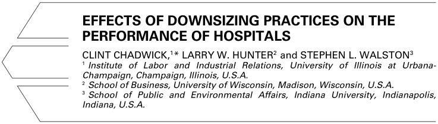

**text found inside the figure**

**EFFECTS OF DOWNSIZING PRACTICES ON THE PERFORMANCE OF HOSPITALS**

CLINT CHADWICK,<sup>1</sup>* LARRY W. HUNTER<sup>2</sup> and STEPHEN L. WALSTON<sup>3</sup>

1 Institute of Labor and Industrial Relations, University of Illinois at Urbana- Champaign, Champaign, Illinois, U.S.A. 2 School of Business, University of Wisconsin, Madison, Wisconsin, U.S.A. 3 School of Public and Environmental Affairs, Indiana University, Indianapolis, Indiana, U.S.A.

*Research has found that downsizing is not generally followed by improved organizational performance. Using a sample of hospitals that recently downsized, we evaluate the effects on performance of the human resource management (HRM) practices used in layoffs. Strategic HRM theory suggests that practices can have an impact on performance outcomes. We find that showing consideration for employees’ morale and welfare during downsizing is positively related both to perceived success of downsizing and to financial performance following layoffs. Advance notice of layoffs is positively related to subsequent financial performance, but the provision of extended insurance to laid-off employees is negatively related to financial performance. Planned redesign of work structures is positively related to perceived success, but has neutral to negative effects on financial performance.* Copyright 2004 John Wiley & Sons, Ltd.

Employment downsizing is widespread in U.S. business. The evidence suggests, however, that downsizing does not typically result in subsequent improvements in organizational performance. Prescriptive writing, case studies, and research on individuals suggest that ineffective downsizing is often associated with unsuccessful approaches to human resource management (HRM). In this paper, we draw on the strategic HRM literature to develop a framework for distinguishing organizational approaches to downsizing and to test empirically whether variation in performance subsequent to downsizing is associated with the human resource practices accompanying layoffs.

Key words: downsizing; human resource management; performance; hospitals ∗Correspondence to: Clint Chadwick, 235 LIR Building, University of Illinois at Urbana-Champaign, 504 E. Armory Ave., Champaign, IL 61820-6297, U.S.A. E-mail: cchadwic@uiuc.edu

#### **DOWNSIZING AND PERFORMANCE: A REVIEW**

‘Downsizing,’ the elimination of jobs in an organization, comprises two kinds of job cuts (Cappelli, 2000). Some cuts are driven by reductions in labor demand following on from decreased demand for a firm’s products or services. Firms, however, may also reduce jobs even in environments in which demand is robust, seeking increased operating efficiencies (as technological changes provide opportunities to substitute capital for labor, or to organize work in new ways, for example). This second type of downsizing came to prominence in the 1980s (Cascio, 1993) and, as the economy boomed during the 1990s, even many firms with strong product demand engaged in downsizing (Cappelli, 1999; Cascio, 2002). Cappelli (2000) shows, however, that the factors leading to actual job reductions in either circumstance are similar, presenting evidence to show that downsizing is more closely associated with management practices than with

Copyright 2004 John Wiley & Sons, Ltd. *Received 23 March 2001 Final revision received 17 September 2003*

Page 2

406 *C. Chadwick, L. W. Hunter and S. L. Walston*

economic conditions. Gerhart and Trevor (1996), in a similar vein, show that variability in employment levels across firms is closely associated with managerial incentives and compensation practices. In general, the evidence suggests that downsizing decisions, whether triggered by changing environmental circumstances or by internal reorganization, reflect strategic choices made by managers. Some firms downsize even as their markets expand; others respond to market declines without undertaking job cuts.

Despite the popularity of downsizing as a strategic initiative, however, the general consensus among researchers over the past two decades is that organizational performance is as likely to suffer as it is to improve after downsizing, even in the short term, and that the long-term prospects associated with downsizing are decidedly negative when compared to alternatives such as targeting growth (Cascio, 1993, 2002; Harari, 1992; Labich, 1996). A number of studies find that downsizing announcements have a negative effect on subsequent stock price (Abowd, Milkovich, and Hannon, 1990; Hallock, 1998; Iqbal and Shetty, 1995; Worrell, Davidson, and Sharma, 1991). A study by Cascio (2002) shows that, on average, downsizing does not yield financial payoffs in the long term.

Some observers suggest that the continued popularity of downsizing despite its ineffectiveness is evidence of its institutionalization as a strategic approach (McKinley, Zhao, and Rust, 2000). Reports of average performance effects, however, mask variation in success in carrying out downsizing across organizations. Madrick (1995), for example, reported results from an American Management Association survey suggesting that while one-third of downsizing organizations experienced subsequent productivity improvements, another one-third reported that their post-downsizing productivity actually worsened. As Cascio, Young, and Morris (1997) argue, the factors that distinguish successful from unsuccessful downsizing require further investigation.

One set of distinguishing factors may be the ways in which firms address the human resource questions raised by the decision to downsize. Human resource management practices play a central role in prescriptive accounts of what makes for successful downsizing (Cameron, Freeman, and Mishra, 1991; Mishra, Spreitzer, and Mishra, 1998; Cascio, 2002). The effects of human resource practices on organizational performance, however, are

generally inferred from case studies and from summaries of research on individuals’ reactions to downsizing. In this paper we present a crossorganizational empirical examination of the effects of such practices on performance, drawing on the strategic human resource management literature to provide a framework for the analysis. For a sample of hospitals that undertook downsizing, we combine data from original primary surveys of human resource practices with publicly available data on hospital characteristics and financial performance to compare, at the organizational level, the effects of practices recommended by previous studies of individuals’ perceptions, reactions, and efforts during and after downsizing.

#### **STRATEGIC HUMAN RESOURCE MANAGEMENT AND DOWNSIZING**

Increasingly, as firms create value through the provision of services and by means of fragile tacit knowledge, human and social capital provide key sources of competitive advantage (Hitt, 2001; Pfeffer, 1994). In effective organizations, employees have valuable skills, employees direct their discretionary effort toward organizational goals, and work is organized in a way that allows for employees’ skills and efforts to be translated into strategically valuable firm capabilities (Bailey, 1993). Connecting this argument with the resource-based view of the firm is the literature addressing the strategic role of HRM (Becker and Gerhart, 1996). Discretionary effort, human capital, and organizational capital have the potential to meet the resource-based view’s criteria for creation of competitive advantage: value, rareness, inimitability, non-substitutability, and immobility (Peteraf, 1993). Studies of the effects of firm- and establishment-level human resource practices show empirically that ‘high-performance work practices’ designed to motivate employees, to build skills and human capital, and to establish effective organizational structures are associated with productivity and financial payoffs (Huselid, 1995; Koch and McGrath, 1996; MacDuffie, 1995).

Thus, though downsizing may yield immediate reductions in direct labor costs, the strategic HRM perspective suggests that it may also undermine longer-term competitive advantage. Focusing

Copyright 2004 John Wiley & Sons, Ltd. *Strat. Mgmt. J.*, **25**: 405–427 (2004)

Page 3

*Downsizing Practices and Hospital Performance* 407

on cost reductions can weaken subsequent performance by undermining discretionary effort, eroding skill bases, and weakening the organizational structures that enhance productivity. Employee reactions to downsizing can include reduced discretionary effort through diminished ‘organizational citizenship behavior’ (Bies, Martin, and Brockner, 1993) and other negative responses to perceived threats posed by layoffs (Mishra and Spreitzer, 1998). Lowered commitment (Davy, Kinicki, and Scheck, 1991), withdrawal from the organization (Davy *et al*., 1991; Brockner, 1990) and from the job (Brockner, 1990) may lead to reduced effort and turnover. And Fisher and White (2000) and Shah (2000) show that layoffs can disrupt workplace relationship networks that are conducive to organizational learning and improvement over time. Cappelli (2000), analyzing a large sample of U.S. establishments, finds two effects consistent with this framework. First, downsizing initially reduces labor costs, resulting, on average, in direct savings. Second, downsizing is followed, on average, by reductions in establishment-level productivity over time, such that the net effect of job cuts on financial performance is neutral to negative for the average establishment.

Successful performance following downsizing therefore requires HRM practices that continue to promote discretionary efforts of employees, that retain valuable human capital, and that reconstruct valuable organizational structures. In the following section we develop hypotheses regarding these practices. Managers are likely to be uncertain about the relationship between specific choices in HRM practices that accompany downsizing and about the net costs and benefits of those choices. There may even be organizational dysfunctions associated with managerial agency, should the managers that implement downsizing decisions not be the same as those who run the organization subsequent to the effects of those decisions, or should managerial contracts reward immediate successes in reducing costs disproportionate to longer-term achievements in preserving productivity (see Shleifer and Summers, 1988, for an analogous discussion of managerial behaviors associated with hostile takeovers). Thus, while there are reasons to expect that better and worse ways to implement downsizing exist, we also expect that the identity of better practices is not always obvious, that such practices will not be ubiquitous, and that some long-term performance advantages may

accrue to organizations able to implement those practices.

In sum, the literature suggests that downsizing has been motivated by external pressures including both excess capacity and increasing demands for operating efficiency. Yet job cuts lead to performance results that are, at best, mixed. We suggest that such results are attributable in part to variation in the way that firms manage their human resources through downsizing. This turns our attention to the following question: given the decision to downsize, can the way in which firms actually go about downsizing make a difference for post-downsizing performance?

#### **HYPOTHESES**

In this section, we identify practices that may lead to higher performance following downsizing. To do so, we review research that examines the effects of downsizing at the individual level, case-oriented research, and prescriptive writing on downsizing. We seek to identify practices that enable us to assess empirically the claim suggested by our theoretical discussion: that variation in financial performance subsequent to downsizing is associated with differences in the HRM practices that accompany downsizing. In order to be effective, such practices should promote continued discretionary effort, help to retain valuable human capital, and preserve effective organizational structures during and after downsizing.

We consider practices that accompany layoffs, or the termination of workers’ employment for reasons not immediately related to those workers’ performance. We recognize that workforce reductions may be achieved through other means (such as attrition or early retirement, for example). Research on the effects of downsizing, however, most typically addresses layoffs or other events that create substantial dislocation for employees, and we draw chiefly on this research to develop our hypotheses. We focus on four kinds of downsizing practices: practices that emphasize the morale and welfare of employees during the process of downsizing; the extent to which firms offer employees advance notice of layoffs; the provision of valuable economic benefits to laid-off workers; and the extent to which downsizing is supported by work redesign featuring careful analysis of jobs and consideration of organizational structures. We

Copyright 2004 John Wiley & Sons, Ltd. *Strat. Mgmt. J.*, **25**: 405–427 (2004)

Page 4

408 *C. Chadwick, L. W. Hunter and S. L. Walston*

consider whether these kinds of practices are likely to have effects on the financial well-being of the organizations in our sample.

#### **Consideration for employees**

Layoffs affect not only those workers whose employment is terminated, but also ‘survivors’ of the downsizing process, whose continued efforts remain vital to organizational success (Brockner, 1992). Remaining workers form attributions about their employers’ intentions after observing how downsizing is carried out. These attributions influence their subsequent discretionary efforts and their willingness to stay with the organization. We consider a range of practices that may affect such attributions.

Downsizing practices may affect survivors by addressing the job insecurity that downsizing produces. Job insecurity generates stress, which in turn may manifest itself in dissatisfaction, intent to leave the organization, greater absenteeism, higher turnover, and disability claims (Boroson and Burgess, 1992; Koco, 1996; Mishra and Spreitzer, 1998; Tombaugh and White, 1990). Postdownsizing, workers are more motivated at moderate than at high levels of job insecurity (Brockner, Tyler, and Cooper-Schneider, 1992). Credibly reestablishing some job security after downsizing should increase most workers’ post-downsizing productivity and thus be associated with better organizational performance. This may not require guarantees of continued employment. Indeed, many organizations do not guarantee long-term employment to survivors, but instead acknowledge downsizing as part of a continuous process of adaptation to changing competitive conditions (Devries and Balazs, 1997). In lieu of guarantees, organizations may offer survivors ways to enhance their marketability, such as skills training and career management training (Louchheim, 1991/1992). Survivors who believe that their organizations are committed to keeping them employable may reciprocate with greater commitment to their current jobs, and such organizations may also be more likely to retain valued workers who have good labor market options.

Organizations may also preserve at least some trust between managers and employees by increasing the amount and frequency of communication with employees during a downsizing program

(Mishra and Spreitzer, 1998). Offering employees a detailed, convincing rationale for initiating downsizing (Feldman and Leana, 1993) reduces survivors’ subsequent job insecurity. The degree of dignity and compassion afforded to terminated colleagues during the intrinsically demeaning downsizing process (Feldman and Leana, 1993; Sutton, Eisenhardt, and Jucker, 1986) also affects survivors’ expectations about how they will be treated in the future. Violations of employees’ dignity can arouse feelings of compassion and indignation among survivors that can reduce their commitment to the organization and their productivity.

Thus we posit that among downsizing organizations, those that implement practices displaying consideration for employees’ morale and welfare will perform better than those that do not. Attention to these issues should increase discretionary efforts and should also reduce subsequent voluntary turnover among survivors with marketable skills, enhancing the firm’s pool of human capital. Specifically, those organizations working to increase survivors’ sense of job security and marketability, to preserve the dignity of terminated employees, to carefully explain the reasons behind downsizing decisions, to communicate more extensively with employees during the downsizing process, and to counsel survivors throughout the process ought to have better performance following the implementation of a downsizing program.

*Hypothesis 1: Organizations that implement downsizing through practices that show consideration for employee morale and welfare will have better post-downsizing performance.*

#### **Advance notice**

Downsizing organizations vary in the extent to which they provide employees with advance notice of layoffs. Advance notice is more directly expensive than immediate layoffs. To the extent that managers delay implementation in order to allow individuals targeted for downsizing a particular level of notice, their firms incur added costs, particularly should these employees’ effort levels decline. Some managers also fear that extensive advance notice will allow disgruntled employees to do considerable damage to the organization before leaving.

Such advance notice, however, may allow dismissed employees extra time to explore their

Copyright 2004 John Wiley & Sons, Ltd. *Strat. Mgmt. J.*, **25**: 405–427 (2004)

Page 5

*Downsizing Practices and Hospital Performance* 409

options in the job market, can give time for both survivors and terminated employees to adjust to the changes, and may also send a message of concern to survivors that is consistent with other aspects of an approach to downsizing that emphasizes longer-term effects on employee morale and welfare (Ting, 1996; Brockner *et al*., 1992; Guinn, 1988). Overall the existing literature suggests that, especially for survivors, advance notice can lessen distractions and disaffection and allow them to focus on their work.

*Hypothesis 2: Organizations that provide more extensive advance notice of layoffs to employees will have better post-downsizing performance.*

#### **Financial benefits**

Organizations may extend financial benefits to terminated employees that go beyond these organizations’ legal obligations. Common forms of financial benefits for downsized employees include severance pay and the extension of health insurance coverage (‘COBRA’) beyond the legally required minimum (Guinn, 1988).

Like advance notice, the provision of financial benefits requires organizations to incur direct costs. Despite these costs, however, such practices offer potential subsequent payoffs. Benefits may mitigate the immediate negative impact of downsizing on displaced employees and may also have positive spillover effects on survivors. The processes which have been found to enhance survivors’ postdownsizing motivation and productivity via consideration of their welfare and interests should also apply when organizations offer financial benefits to employees who have been laid off.

*Hypothesis 3: Organizations that provide severance pay and extended insurance coverage to laid-off employees will have better post-downsizing performance.*

#### **Work redesign**

The strategic HRM approach suggests that organization and work structures that are appropriately designed are associated with performance advantages. Downsizing provides an opportunity for work redesign, but not all downsizing organizations seize such opportunities. Cameron (1994) distinguishes between downsizing strategies that

focus solely on workforce reduction and those that accompany downsizing with planned work redesign focusing on reconfiguration of jobs and organizational structures. Market reactions here are mixed: Worrell *et al*. (1991) showed that stock price gains followed announcement of restructuring plans to accompany downsizing efforts, though Cascio (2002) suggests that longer-term market returns to restructuring are less favorable.

Effective work redesign requires attention both to specific jobs and to broader organizational structures. Downsizing without such planning, in contrast, may damage organizational capabilities by discarding valuable skills and by disrupting relationship networks and institutional memory through indiscriminate dismissals of key individuals (Dougherty and Bowman, 1995; March, 1991; Shah, 2000). Thus we hypothesize that organizations in which downsizing is part of a larger plan for organizational design and in which systematic analyses of jobs in the organization accompany layoffs should have better performance following the implementation of a downsizing program.

*Hypothesis 4: Organizations that implement downsizing with planned redesign of work will have better post-downsizing performance.*

#### **CONTEXT: THE U.S. HOSPITAL INDUSTRY**

We consider the effectiveness of downsizing practices in the U.S. hospital industry. Prior to the mid-1980s, hospitals operated in a relatively stable environment. Major amendments to Medicare legislation in 1983 and the rise of managed care, however, subsequently changed the world in which hospitals operate dramatically. Managed care (e.g., HMOs) increasingly caused hospitals to become much more conscious of their cost structures and to be more explicitly oriented toward efficiency (Alexander and D’Aunno, 1990).

The two forces identified by Cappelli (2000)— excess capacity and shifts in the production function enabling the use of fewer workers for a given level of service—were both at work in the industry. With the implementation of Medicare Prospective Payment in the mid-1980s, inpatient utilization and respective bed occupancy in hospitals fell

Copyright 2004 John Wiley & Sons, Ltd. *Strat. Mgmt. J.*, **25**: 405–427 (2004)

Page 6

410 *C. Chadwick, L. W. Hunter and S. L. Walston*

every year from 1984 to 1997 (Hull, 1992; Bellandi, 1999). By 1997 only about 60 percent of hospital capacity was filled and efforts to address this excess capacity had reached unprecedented levels (Wright, 1997). The increasing technical feasibility and desirability of outpatient services led managers to seek further job cuts as inpatient volumes migrated to outpatient settings. Meanwhile, through reengineering initiatives, managers sought to reorganize work to achieve job reductions as the number of services offered were held constant or increased (Walston, Burns, and Kimberly, 2000). One national study, for example, found that 60 percent of U.S. hospitals had implemented reengineering between 1990 and 1995 (Walston, Kimberly, and Burns, 2001), and of these, 82 percent accompanied reengineering with job reductions. Recurring shortages of particular groups of employees (for example, nurses) also led managers to search for ways to do more with fewer workers (Fulmer, Mezey, and Siu, 1999).

For several reasons, hospitals provide a good venue for exploring relationships between downsizing practices and subsequent performance during the period. First, the industry is typical in that evidence suggests that downsizing has generally failed to deliver the expected benefits (Mick and Wise, 1996; Curtin, 1994). Some hospitals, however, have been more successful following downsizing than others, raising the possibility that performance might be related to the ways in which hospitals have gone about reducing jobs. Second, this context is one in which strategic HRM theory suggests that human resources could influence performance: discretionary effort by employees matters; human capital is valuable; and workforce structures can be influential (Gittell *et al*., 2000; Gittell, 2002; Preuss, 2003). Third, financial performance measures are available for many hospitals at the establishment level. At this level, measures of human resource practices can be obtained with higher levels of reliability than at the firm level (Gerhart *et al*., 2000).

The single-industry design has a further advantage of providing additional kinds of control for some forms of firm heterogeneity that might covary with downsizing practices. The environment faced by the organizations in our study has more similarity than would a sample that comprised multiple industries (for example, in approaches to restructuring work). Our sample is thus relatively homogeneous with respect to these key external factors,

and further, where hospitals do face varying circumstances, we are able to identify more precisely and control for the sorts of variables that might provide alternative explanations for our results.

#### **Data sources**

We combine information from two original surveys and from two archival data sources for this study. The first original survey, conducted in the winter of 1996–97, was targeted at hospital chief executive officers and other upper managers of all U.S. acute care hospitals larger than 100 beds. This survey chiefly addressed hospital reengineering and restructuring. The second survey, conducted in 1997, was a follow-up that was sent to senior HR managers of hospitals that responded to the first survey. This survey asked respondents to report on the most recent downsizing episode in their hospital if at least one had occurred within the 1991–96 time period. The HR managers were better positioned than CEOs or other possible respondents to provide accurate descriptions of these hospitals’ downsizing practices.

We matched data from these two surveys to data for each hospital from the American Hospital Association (AHA) annual surveys and from Van Kampen Merritt (VKM) Investment Advisory Corporation. The AHA surveys provided information on hospital characteristics, and VKM provided financial performance measures for all hospitals that had issued tax-exempt bonds in the preceding decade. Credit analysts, investment bankers, and other investment professionals rely on VKM (now Merritt Research Services, LLC) data to conduct municipal credit analysis. VKM has a strong reputation for the accuracy of its data, and has especially strong incentives to provide accurate data for financially struggling hospitals (such as those undertaking downsizing), as these data will influence decisions that are crucial to investors.

#### **Sample bias**

Because we focus our attention on the effectiveness of downsizing practices, we considered only

Copyright 2004 John Wiley & Sons, Ltd. *Strat. Mgmt. J.*, **25**: 405–427 (2004)

Page 7

*Downsizing Practices and Hospital Performance* 411

hospitals responding to both the first and the second (follow-up) surveys. There were 161 respondents to the second survey, representing 6.8 percent of the total of 2370 U.S. acute care hospitals larger than 100 beds in urban areas. Of these respondents, 116, or 72.0 percent, reported on a recent downsizing. 114 of these responses were usable. Chi-square tests suggested response bias by two observable factors: geographic region and governance status. For-profit hospitals and those from the New England area were less likely to respond. Hospitals in East North Central States (Ohio, Indiana, Illinois, Michigan, and Wisconsin) were overrepresented.

Failure to account for the characteristics associated with survey response may lead to incorrect inferences regarding the impact of the independent variables (Heckman, 1979). Thus we added Heckman-style bias correction terms to all of the regression analyses reported below, using a probit regression to model the likelihood of exclusion from the research sample based on regional location and governance status, as well as membership in a hospital system, regional location, membership in the Council of Teaching Hospitals, membership in a healthcare alliance, and hospital size (in beds). Our base group was the population of all hospitals larger than 100 beds in Standard Metropolitan Statistical Areas (SMSAs). Inclusion of these correction terms did not substantively affect our results in any models we estimated, and we therefore omitted it from the models for which we report results.

#### **Missing data**

Because the combined data set is small, even a modest amount of missing data poses a potentially serious concern. Casewise deletion of observations with any missing data in an analysis using the full set of variables that we investigate reduced the usable sample to 12 cases, though data in only 11.6 percent of all cells were missing. Therefore, we employed expectation maximization (EM), which utilizes maximum likelihood to converge iteratively on estimates of missing values, to impute missing data. Analyses using EM estimates of missing data have been demonstrated to be generally more consistent and efficient than those using regression imputation, mean substitution, casewise deletion, or pairwise deletion. This advantage may be especially pronounced as the amount of missing

data increases (Arbuckle, 1994). For ordinal variables, we rounded the imputed values to the nearest integer. We truncated imputed values at zero for the continuous variables for which negative values had no meaning (Schafer, 1997). We excluded the dependent variables from this imputation.

#### **Dependent variables**

We analyzed two different kinds of outcomes that could yield insight into the effectiveness of downsizing practices. First, we examined HR managers’ perceptions of the overall success of their hospitals’ downsizing efforts. Perceptions of success are commonly used in evaluations of the effectiveness of human resource practices (for an example, see Delaney and Huselid, 1996). Still, results for this variable could be shaped by a number of factors in addition to performance subsequent to downsizing, so results using this variable must be interpreted cautiously. First, because the survey asked for an assessment of the success of the downsizing itself rather than for a more comprehensive performance assessment, downsizing practices that were perceived to have been successful may not have been related to overall hospital performance. Further, common method bias (Podsakoff and Organ, 1986) could result because this dependent variable was obtained from the same survey as the independent variables measuring downsizing practices. Acceptance by respondents of particular approaches to downsizing as normative ‘best practices’ could, for example, lead to inflated estimates of their relationships with perceived success. We return to these issues in discussing results for perceived success, below.

Second, we employed a bottom-line measure of organizational effectiveness: cash margin, or the ratio of free cash available for a hospital’s use to the total hospital net revenues. Cash margin is a common measure of hospitals’ financial flexibility and organizational strength (Cerne, 1993; Cleverly, 1984); it indicates the amount of cash retained after payment of principal and other cash expenses as a percentage of total revenue. Our literature review led us to expect that observed effects on financial performance would emerge subsequent to downsizing. Cascio *et al*. (1997), for example, find effects on financial performance for more than 2 years following downsizing. We made no *a priori* predictions about the specific timing of lagged effects on performance of our study variables, but

Copyright 2004 John Wiley & Sons, Ltd. *Strat. Mgmt. J.*, **25**: 405–427 (2004)

Page 8

412 *C. Chadwick, L. W. Hunter and S. L. Walston*

examined cash margin in the year of downsizing, and 1, 2, and 3 years following downsizing.

#### **Independent variables: downsizing practices**

The survey elicited organizations’ downsizing practices by asking for responses to Likert-style questions. Table 1 provides detailed descriptions of these items. To measure hospitals’ consideration for employees, provision of advance notice, and planned work redesign, we combined two or more survey questions into scales. We constructed each scale by taking the mean of its component variables.

Our measure of consideration for employees is a scale, *Consideration*, comprising six highly correlated items (Cronbach’s *α* = 0*.*71). Individual items included respondents’ assessments of the degree to which their organizations attempted to increase job security, increase survivors’ marketability, preserve the dignity of downsized employees, to carefully explain the reasons behind downsizing decisions, to communicate more extensively with employees, and to counsel survivors.

The survey contained two questions regarding advance notice. One question asked about the amount of time between the general announcement of downsizing and the notice given about which specific employees would be downsized. The other question asked about the amount of time between notice being given to specific employees of their termination and the date that these employees actually separated from the organization. We combined these two measures into a scale, *Advance notice* (Cronbach’s *α* = 0*.*74), to indicate the extent to which the organization provided advance notice as a downsizing practice.

We measured financial benefits with two binary variables. The survey asked whether or not hospitals extended employees’ severance pay, and insurance benefits beyond the legally required period, to laid-off employees. The survey did not identify actual costs of these practices. We therefore assigned a value of ‘1’ if the hospital offered the

benefit, and a ‘0’ if it did not, to the variables *Severance pay* and to *Extended insurance*.

We operationalized the extent to which downsizing was associated with plans for work and organizational redesign with two survey questions asking about the degree to which a detailed plan existed for downsizing and the extent to which a systematic job analysis was performed prior to downsizing. The two-item scale, *Planned work redesign*, had lower than desirable reliability (Cronbach’s *α* = 0*.*58); we examine the implications of this and consider alternatives below.

#### **Control variables**

As control variables, we considered a set of factors that are regularly associated with differences in hospital performance in the healthcare management literature: local market concentration; health maintenance organization (HMO) local market penetration; the existence of unionization; ownership structure; and hospital size. Market concentration may potentially affect hospital performance by reflecting the intensity of local competition (Reed, Lemak, and Montgomery, 1996). Our *Market concentration* measure was a Herfindahl–Hirschman index of hospital size in the local market in 1995 (Phibbs and Robinson, 1993). The *HMO penetration* measure, which indicates the percent of the population of a metropolitan statistical area (MSA) enrolled in an HMO in 1995, captures further important differences in the intensity and type of local market competition. We measured *Unionization* with a dummy variable indicating whether any of the hospital’s employees belong to a union. Dummy variables indicating *For-profit* and *Government-run status* measured ownership structure. Organizational size was measured by the number of licensed hospital *Beds*, a common size measure for hospitals.

Downsizing events themselves also differ across hospitals. To account for these differences, we included a variable measuring the *Share of employees laid off*, taking the reported number laid off as a percentage of hospitals’ full-time equivalent employees to represent the size of the downsizing event. We also considered the different kinds of circumstances that could motivate downsizing. *Change in occupancy rate* indicates excess capacity, and is measured by the change in the occupancy rate at the hospital. *Shifts to outpatient services* are measured by the change in the share of

Copyright 2004 John Wiley & Sons, Ltd. *Strat. Mgmt. J.*, **25**: 405–427 (2004)

Page 9

*Downsizing Practices and Hospital Performance* 413

Table 1. Descriptive statistics

Variable Description Mean S.D. *N* Source

*Dependent variables*

Cash margin year before Ratio of free cash available for a hospital’s use to total hospital net 8.13 4.69 57 VKM

downsizing revenues. Indicates cash retained (after payment of principal and other

Cash margin year of cash expenses) as a percentage of total revenue 8.38 4.60 58 VKM

downsizing

Cash margin year following

downsizing 8.71 5.92 60 VKM

Cash margin 2nd year

following downsizing 9.19 6.92 57 VKM

Cash margin 3rd year

following downsizing 9.26 5.58 57 VKM

Perceived success Overall, our downsizing efforts were successful (5-point Likert response; higher

numbers indicate greater agreement) 3.65 0.92 107 2nd

*Study variables*

Consideration for employee

welfare and morale Six-item scale calculated as the mean of 5-point Likert responses to the following

items (Cronbach’s *α* = 0*.*71). Higher numbers indicate greater agreement (e.g.,

1 = strongly disagree, 5 = strongly agree): 1. We have undertaken efforts to increase remaining employees’ sense of employment security with our company

2. We have undertaken efforts to increase employees’ confidence in the marketability of their skills

3. We made careful efforts to preserve employee dignity during the downsizing process

4. The reasons for an employee’s layoff or redeployment were carefully explained to affected employees

5. During the course of downsizing, management increased the amount of openness and communication with employees

6. We carefully trained middle- and lower-level managers in procedures for counseling remaining employees

3.75 0.63 114 2nd

Advance notice Two-item scale on notice given to employees in advance of downsizing events,

calculated as the mean of 6-point Likert responses (Cronbach’s *α* = 0*.*74).

Higher numbers indicate more time allowed (e.g., 1 = none, 6 ⩾than 4 weeks):

1. Please estimate the typical amount of time between the general announcement of a downsizing program and notice being given to specific employees targeted

for layoff during downsizing

3.41 0.69 114 2nd

(*continued overleaf* )

Copyright 2004 John Wiley & Sons, Ltd. *Strat. Mgmt. J.*, **25**: 405–427 (2004)

Page 10

414 *C. Chadwick, L. W. Hunter and S. L. Walston*

Table 1. (*Continued*)

Variable Description Mean S.D. *N* Source

2. Please estimate the typical amount of time between notice being given to specific employees targeted for layoff during downsizing and the date these

employees were actually separated from your hospital

Extended insurance coverage Offered extended insurance coverage (COBRA) beyond legally required minimum 0.61 0.49 114 2nd Severance pay Offered severance pay to laid-off employees 0.89 0.32 114 2nd Planned work redesign Two-item scale on strategic planning in downsizing, calculated as the mean of

5-point Likert responses to the following items (Cronbach’s *α* = 0*.*58). Higher numbers indicate greater agreement (e.g., 1 = strongly disagree, 5 = strongly

agree):

1. Prior to embarking on downsizing, a detailed plan existed for how the residual organization would look after the downsizing

2. Our company prepared a systematic analysis of jobs months prior to the downsizing

3.51 1.07 114 2nd

*Control variables*

Local market concentration Herfindal index by beds for local market as of 1995 0.09 0.09 114 AHA

HMO penetration Percent of the population in hospital’s MSA enrolled in an HMO as of 1995 0.23 0.12 114 AHA

Hospital size Total licensed hospital beds 307.6 200.4 114 AHA

Government facility Hospital is government-affiliated (dummy) 0.13 0.34 114 AHA

For-profit facility Hospital is a for-profit entity (dummy) 0.05 0.22 114 AHA

Unionized Any portion of workforce covered by union contract (dummy) 0.37 0.48 114 2nd Strategic HRM Strategic HR management role, calculated as the mean of 5-point Likert responses

to the following items (Cronbach’s *α* = 0*.*72). Higher numbers indicate that the

firm more regularly engages in the listed activity:

1. Match the characteristics of managers to the strategic plan of the hospital 2. Identify managerial characteristics necessary to run the hospital in the long term

3. Modify the compensation system to encourage managers to achieve long-term strategic objectives

4. Change staffing patterns to help implement business or corporate strategies 5. Evaluate key personnel based on their potential for carrying out strategic goals 6. Conduct job analyses based on what the job may entail in the future 7. Conduct development programs designed to support strategic changes

3.06 0.73 114 2nd

Share of employees laid off Share of employees, in FTEs, laid off as a result of indicated downsizing event 0.048 0.072 114 1st Excess capacity Change in occupancy rate from 2 years prior to downsizing event to time of

downsizing event −0.02 0.06 114 AHA

Shift to outpatient services Change in outpatient rate from 2 years prior to downsizing event to time of

downsizing event 0.01 0.03 114 AHA

Source key: 1st = First survey, 2nd = Second survey, AHA = American Hospital Association, VKM = Van Kampen Merritt (see text for details). *N* includes variables imputed with

maximum-likelihood estimation.

Copyright 2004 John Wiley & Sons, Ltd. *Strat. Mgmt. J.*, **25**: 405–427 (2004)

Page 11

*Downsizing Practices and Hospital Performance* 415

patients served in outpatient settings. To ensure that we had identified circumstances that clearly preceded the downsizing event, we looked at the annual changes in each, culminating in the year preceding the downsizing event. (We also considered other ways of measuring these variables; we discuss the alternatives below.)

An organization’s downsizing methods might be part of a more general approach to strategic human resource management. If this were true, effects attributed to specific downsizing practices might actually be the consequences of general HRM. To address this concern, we constructed a scale (Cronbach’s *α* = 0*.*72) based on items in the surveys for Huselid (1995) by taking the mean of seven 5-point Likert-type questions indicating whether the organization manages its human resources strategically. We used this scale, *Strategic HRM*, as an additional control variable in our analyses (see Table 1 for details).

We also employed the cash margin for the year prior to the downsizing event as a control variable. Cash margins from year to year are highly correlated, for reasons related both to observable variables and to unobserved factors. To the extent our results converged for models controlling for prior financial performance and for those that did not, we could be more confident that we had accounted for unobserved factors and that the effects we associated with our variables of interest were less likely to be attributable to unobserved heterogeneity in the sample.

#### **Downsizing practices and their determinants**

Table 2 reports correlations between the variables. The correlations among the downsizing practices show that hospitals’ consideration for employees and planning with respect to organizational and work redesign are not independent: the two scales are correlated positively and significantly. Further investigation suggested that the individual items in these two scales could have been combined into one scale with acceptable reliability (Cronbach’s *α* = 0*.*71). We chose to use distinct scales, however, for two reasons. First, our theoretic discussion suggests that these are two separate domains, so the comparison between the two is substantively important. Second, the two kinds of questions measure organizational activity at different

levels. The human relations scale examines organizational practices that affect individual employees, while the planned redesign scale measures organizational level activity. We discuss the implications of employing separate scales below.

Before considering our hypotheses regarding the effects of downsizing practices, we examined the determinants of those practices in order to identify factors that might have influenced hospitals’ approaches to downsizing. We separately regressed each of our measures of downsizing practice on the set of control variables, employing ordinary least squares estimates for the continuous variables, and logistic regression for the binary measures. Results of these analyses are displayed in Table 3.

Overall the results in Table 3 were consistent with the zero-order correlations that are documented in Table 2. Structural and organizational factors bore few relationships to the practices of hospitals in implementing downsizing. Fit between these variables and the downsizing practices was quite low and there were only a small number of significant regression coefficients, with few patterns across the different models. Neither the bivariate correlations in Table 2 nor the multivariate estimates in Table 3 suggest, generally, that differences in the human resource management practices accompanying downsizing were closely related to characteristics of the hospitals or their environments. The models predicting advance notice (Table 3, Column 2) and extended insurance coverage (Table 3, Column 4) offered little overall explanatory power. Fit for the models predicting consideration for employees (Table 3, Column 1) and planned work redesign (Table 3, Column 3) was driven chiefly by the extent to which hospitals report approaching human resource management strategically.

Table 3 features two patterns of results. First, available funds influenced the hospitals’ approaches to downsizing. The cash margin in the year prior to downsizing was a positive, significant predictor of two kinds of practice: more extensive advance notice to laid-off employees and the provision of severance pay. Each of these practices requires a direct cash outlay. We note that nearly 90 percent of the hospitals offered severance pay; financial distress was evidently a key factor in determining whether a hospital was in the small group that did not offer severance pay. For-profit facilities were also less likely to offer severance pay.

Copyright 2004 John Wiley & Sons, Ltd. *Strat. Mgmt. J.*, **25**: 405–427 (2004)

Page 12

416 *C. Chadwick, L. W. Hunter and S. L. Walston*

Table 2. Pearson correlation matrix for principal variables in the analysis (pairwise)

1 2 3 4 5 6 7 8 9 10 11

1 Cash margin year before event 1.00 2 Cash margin year of event 0.73∗ 1.00 3 Cash margin 1st year following 0.44∗ 0.70∗ 1.00 4 Cash margin 2nd year 0.47∗ 0.60∗ 0.75∗ 1.00 5 Cash Margin 3rd year 0.50∗ 0.59∗ 0.61∗ 0.78∗ 1.00 6 Perceived success −0.07 −0.03 0.06 0.06 −0.01 1.00 7 Consideration for employees 0.07 0.16 0.22∗ 0.22∗ 0.22∗ 0.36∗ 1.00 8 Advance notice 0.26∗ 0.30∗ 0.30∗ 0.30∗ 0.29∗ 0.01 0.12 1.00 9 Extended insurance coverage 0.01 −0.06 −0.18 −0.21∗ −0.16 −0.02 0.05 0.11 1.00 10 Severance pay 0.31 0.31∗ 0.15 0.11 0.14 −0.04 0.11 −0.12 0.11 1.00 11 Planned work redesign 0.02 0.02 0.01 −0.02 −0.09 0.37∗ 0.32∗ 0.02 −0.08 0.00 1.00 12 Local market concentration 0.18 0.24∗ 0.26∗ 0.27∗ 0.25∗ −0.02 0.11 −0.05 0.03 0.10 0.19∗ 13 HMO penetration −0.25∗ −0.17 −0.09 −0.22∗ −0.28∗ 0.00 0.11 0.08 0.09 −0.02 0.06 14 Hospital size −0.17 −0.23∗ −0.21 −0.17 −0.16 −0.11 −0.05 −0.09 −0.09 0.11 0.09 15 Government facility 0.16 0.13 0.10 0.15 0.12 −0.25 −0.04 0.11 −0.11 −0.02 −0.16

16 For-profit facility — — — — — 0.00 −0.08 −0.09 −0.13 −0.28∗ −0.02

17 Unionized −0.30∗ −0.19∗ −0.02 −0.12 −0.08 0.00 −0.03 0.09 −0.13 0.05 0.07 18 Strategic HRM 0.13 0.19∗ 0.14 0.10 0.02 0.17 0.34∗ 0.00 0.09 0.08 0.41∗ 19 Share of employees laid off −0.00 −0.07 −0.14 −0.08 0.01 −0.13 −0.20∗ 0.03 0.03 −0.13 −0.12

20 Excess capacity 0.05 0.02 0.05 0.02 0.08 0.06 −0.14 −0.03 −0.03 −0.01 0.15 21 Shift to outpatient services 0.11 0.16 0.10 −0.05 −0.05 0.23∗ 0.17 −0.01 0.01 −0.13 −0.03

12 13 14 15 16 17 18 19 20 21

12 Local market concentration 1.00 13 HMO penetration −0.21∗ 1.00 14 Hospital size −0.03 −0.08 1.00 15 Government facility −0.03 −0.06 −0.15 1.00 16 For-profit facility −0.10 0.07 −0.20∗ −0.09 1.00 17 Unionized 0.05 0.22∗ 0.17 −0.03 −0.18 1.00 18 Strategic HRM 0.28∗ −0.01 −0.10 −0.10 −0.00 −0.07 1.00 19 Share of employees laid off −0.12 −0.01 −0.09 −0.01 0.22∗ −0.02 −0.12 1.00 20 Excess capacity 0.15 −0.10 0.03 −0.13 −0.21∗ 0.04 0.08 −0.03 1.00 21 Shift to outpatient services −0.03 −0.02 −0.18 −0.04 −0.04 −0.15 0.11 0.13 −0.12 1.00

∗*p <* 0*.*05

Copyright 2004 John Wiley & Sons, Ltd. *Strat. Mgmt. J.*, **25**: 405–427 (2004)

Page 13

*Downsizing Practices and Hospital Performance* 417

Table 3. Models predicting downsizing practices

OLS regression coefficients Logistic regression

coefficients

Consideration for employees

scale

Advance

notice

scale

Planned

work redesign

scale

Extended insurance

coverage

Provision of severance

pay

Constant 2.77<sup>∗∗</sup> 2.25<sup>∗</sup> 1.52<sup>∗∗</sup> 0.01 −1.94 (0.33) (0.92) (0.54) (1.21) (2.25) Cash margin year prior 0.01 0.12<sup>∗∗</sup> 0.01 −0.01 0.47<sup>∗∗</sup> to downsizing (0.01) (0.04) (0.02) (0.05) (0.16) Local market concentration 0.32 −1.72 1.06 1.14 −0.66 (0.67) (1.89) (1.12) (2.53) (6.64) HMO penetration 0.64 1.53 0.59 2.38 0.09 (0.49) (1.38) (0.81) (1.87) (3.71) Hospital size (100 beds) 0.00 −0.07 0.06 −0.13 0.32 (0.03) (0.08) (0.05) (0.11) (0.26) Government facility −0.06 0.20 −0.34 −1.01 −0.99 (0.17) (0.49) (0.29) (0.65) (1.19) For-profit facility −0.25 −0.78 0.19 −2.49<sup>∗∗</sup> −3.68<sup>∗∗</sup> (0.27) (0.77) (0.46) (1.05) (1.46) Unionized −0.02 0.55 0.16 −0.90<sup>∗</sup> 0.74 (0.13) (0.36) (0.21) (0.47) (0.95) Share of employees laid off −1.39† 1.06 −2.77<sup>∗</sup> 3.02 −2.25 in downsizing (0.80) (2.26) (1.33) (3.01) (4.60) Shift to outpatient services 2.33 −3.09 1.09 −5.91 −33.05<sup>∗</sup> (1.81) (5.08) (3.00) (6.76) (14.99) Change in occupancy rate −1.59† −1.31 −0.79 −3.50 −11.90<sup>∗</sup> (0.89) (2.52) (1.48) (3.37) (6.64) Strategic HRM 0.26<sup>∗∗</sup> 0.02 0.53<sup>∗∗</sup> 0.23 0.51 (0.08) (0.23) (0.13) (0.31) (0.57) Log-likelihood — — — −69.95 −24.20 Pseudo-*R*<sup>2</sup> — — — 0.085 0.402 Chi-squared — — — 13.04 32.51<sup>∗∗</sup> (Prob. *>* chi-squared) (0.291) (0.001) Adjusted *R*<sup>2</sup> 0.125 0.045 0.166 — — *F* (Prob. *> F*) 2.46<sup>∗∗</sup> 1.48 3.04<sup>∗∗</sup> — — (0.009) (0.150) (0.002) — — Observations 114 114 114 114 114

Standard errors in parentheses. <sup>∗</sup>*p <* 0*.*05; <sup>∗∗</sup>*p <* 0*.*01; † *p <* 0*.*10

Cash margin prior to downsizing was not associated with practices that required no direct expenditures: consideration for employees and planned work redesign.

The other financial benefit we examined, provision of extended insurance coverage, was also less likely to be offered by for-profit hospitals, but was not associated with the cash margin in the prior year. The difference between this result and the result for severance pay may have to do with the fact that, by law, organizations are required to extend availability of health insurance coverage for 18 months; any hospital extending coverage beyond the legally mandated period would incur

no extra costs until after that period, and thus the immediate cash position of the hospital was relatively less important in the decision to extend this benefit.

A second pattern suggested in Table 3 is that the circumstances of the layoff were associated with practices, though unsystematically. Column 3 shows that the larger the share of employees laid off, the less likely respondents were to report carefully planned work redesign. Larger layoffs were also associated with marginally less consideration for employees. Excess capacity was associated with less consideration and a lower likelihood of severance pay, while shifts to outpatient services

Copyright 2004 John Wiley & Sons, Ltd. *Strat. Mgmt. J.*, **25**: 405–427 (2004)

Page 14

418 *C. Chadwick, L. W. Hunter and S. L. Walston*

were inversely related to the extension of severance pay.

In our sample, the structural features of hospitals and of their competitive environments offered at best modest guidance in predicting use of downsizing practices. The results suggest that variation across hospitals in the practices used to carry out downsizing could be attributed to managerial choices in implementation rather than to characteristics of hospitals or their environments.

#### **Effects on performance**

We turn now to estimates of the effects of downsizing practices on measures of performance. We report results for models estimated on all available observations for each dependent variable. As noted above, corrections for sample bias did not alter these results. Table 4 displays the results of ordered logit estimations of the effects of HRM practices on perceived downsizing success. (We report ordered logit results because the dependent variable takes only the values 1–5; OLS estimates were substantively similar.) Table 5 displays OLS estimates of the effects of practices on cash margin in the year of downsizing, and in subsequent years. In each table, we report results for control models and then for models in which the downsizing practices variables are entered as a block. We discuss the control models before turning to results for each of the hypotheses.

#### **Controls**

Column 1 of Table 4 shows the effects of control variables on perceived success of the downsizing event. Government facilities in our sample were less likely to perceive that downsizing had been successful. To the extent that the downsizing hospital was shifting its mix of services toward outpatient care (our indicator of downsizing driven by technological change rather than by a response to excess capacity), the downsizing was likely to be perceived as more successful. Column 1 also shows that the larger the downsizing, the lower the perceptions of success. In these models we also controlled for cash margin in 1995 (the year likely to be most salient to survey respondents given the date of the survey); perceived success was not related to actual financial performance.

Table 5 displays results for financial performance. In these models, the controls were highly

significant as a group. The control model estimated in Column 1 of Table 5, for example, displays results for a regression of cash margin in the year of downsizing on the reported subset of organizational and structural control variables. The adjusted *r*<sup>2</sup> for this model is 0.26 and the *F*-test (2.83, *p* = 0*.*007) shows that the model offers significant explanatory power. As expected, controlling for financial performance prior to downsizing increases the explanatory power of the models in each year, though not surprisingly the extent of added explanatory power diminished over time. The share of employees laid off had a strong negative relationship to subsequent performance through 2 years following the downsizing event.

Our estimations of effects on financial performance also controlled for other characteristics, as noted above. Cash margin figures were only available for the subset of the hospitals in the data set for which we were able to obtain financial performance from Van Kampen Merritt. The sample for these analyses is thus reduced to 60 or fewer hospitals for any particular year following downsizing. Given the reduced sample size, we report models which include fewer organizational and structural variables than those reported in Table 3 (for the determinants of the practices) or in Table 4 (for perceived performance). We also, however, estimated alternative specifications for different subsets and combinations of the control variables described above, and with other unreported control variables (whether or not the hospital was a member of a multi-hospital system, for example). We considered alternative measures for market conditions and services offered (not just changes in levels of capacity utilization and outpatient services, but the levels themselves, changes over different time periods, and more detailed measures of levels and changes in the range of services offered). Our substantive results for the study variables were unchanged in these models; results for specific models are available on request. The models reported in Table 5 account for considerable heterogeneity across hospitals while preserving degrees of freedom, an important concern given our sample size.

#### **Consideration for employees**

The data provide support for Hypothesis 1, which concerns consideration for employees’ morale and

*Downsizing Practices and Hospital Performance* 419

Table 4. Estimates for ordered logit models for post-downsizing performance. Dependent variable: perceived success of downsizing

Perceived success: ‘Overall, our downsizing

efforts were successful’ 1 = strongly

disagree to 5 = strongly agree

Cash margin 1995 −0.04 −0.00 (0.04) (0.04) Local market concentration −0.86 −3.53 (2.47) (2.67) HMO penetration −0.59 −1.64 (1.61) (1.66) Hospital size (100 beds) −0.15 −0.23<sup>∗</sup> (0.10) (0.11) Government facility −1.49<sup>∗</sup> −1.05 (0.61) (0.67) For-profit facility 0.12 0.05 (0.80) (0.88) Unionized 0.22 0.17 (0.41) (0.44) Share of employees laid off in downsizing −5.73<sup>∗</sup> −1.89 (2.51) (2.73) Change in occupancy rate 1.66 3.72 (2.95) (3.12) Shift to outpatient services 14.90<sup>∗</sup> 9.53 (6.28) (7.18) Strategic HRM — −0.20

(0.32) Consideration for employees — 1.08<sup>∗∗</sup> (0.37) Advance notice — 0.01 (0.12) Extended insurance coverage — 0.04 (0.44) Planned work redesign — 0.75<sup>∗∗</sup> (0.23) Cut point 1 0.05 −5.23 (1.76) (1.01) Cut point 2 1.48 −3.81 (1.68) (0.87) Cut point 3 3.88 −1.74 (1.70) (0.79) Cut point 4 6.70 0.64 (1.80) (0.77) Log-likelihood −127.97 −115.59 Pseudo-*R*<sup>2</sup> 0.071 0.161 Chi-squared (Prob. *>* chi-squared) 19.58<sup>∗</sup> 44.33<sup>∗∗</sup> (0.033) (0.000) Chi-squared/*F* for downsizing practice — 21.13<sup>∗∗</sup> variables (Prob.) (0.000) Observations 107 107

Standard errors in parentheses, <sup>∗</sup>*p <* 0*.*05; <sup>∗∗</sup>*p <* 0*.*01; † *p <* 0*.*10 All models include dummy variables for year of layoff (omitted year = 1990).

welfare. Column 2 of Table 4 shows that consideration was positively associated with the perceived success of the downsizing initiative. With respect to financial performance, estimates for

the year of the layoff and the year following the layoff (Columns 2–5) suggest the effects of consideration were small to none, but results reported in Columns 6–9 indicate that the effects

420 *C. Chadwick, L. W. Hunter and S. L. Walston*

Table 5. OLS regression models for post-downsizing performance. Dependent variable: Reported cash margin

1 2 3 4 5 6 7 8 9

Cash

margin in

year of

layoff

Cash

margin in

year of

layoff

Cash

margin in

year of

layoff

Cash margin

for year

following

layoff

Cash margin

for year

following

layoff

Cash margin

in second

year following

layoff

Cash margin

in second

year following

layoff

Cash margin

in third

year following

layoff

Cash margin

in third

year following

layoff

Cash margin in year — — 0.68∗∗ — 0.42∗ — 0.16 — 0.50 before layoff (0.10) (0.19) (0.20) (0.32)

Local market 10.46† 10.20 5.26 9.00 6.22 25.17∗∗ 24.17∗∗ −9.61 −12.21

concentration (6.16) (6.27) (4.36) (8.94) (8.62) (8.77) (8.90) (14.75) (14.59)

HMO penetration −1.83 −3.14 3.63 −2.01 2.56 −9.65 −7.90 −15.36 −9.81

(4.39) (4.19) (3.04) (5.69) (5.78) (5.82) (6.23) (10.05) (10.49)

Hospital size (100 beds) −0.61∗ −0.47† −0.39∗ −0.50 −0.51 0.25 0.27 −0.13 −0.12

(0.26) (0.28) (0.19) (0.38) (0.37) (0.40) (0.40) (0.67) (0.66)

Government facility 3.25∗ 2.62 −0.65 0.61 −1.31 0.31 −0.56 −0.46 −2.54

(1.61) (1.67) (1.24) (2.23) (2.28) (2.56) (2.79) (4.29) (4.42)

Share of employees −27.75∗ −29.69∗ −17.74∗ −22.31 −15.60 −37.12∗ −34.27∗ −4.95 −0.74

laid off in downsizing (11.05) (11.13) (7.83) (15.59) (15.16) (15.87) (16.33) (25.00) (24.70)

Strategic HRM — 0.42 0.76 0.32 0.32 2.37† 2.39† −2.49 −2.62

(0.82) (0.56) (1.14) (1.09) (1.21) (1.21) (1.84) (1.81)

Consideration for — 1.30 0.27 2.33† 1.38 3.54∗ 3.30† 6.65∗ 6.24∗ employees (1.00) (0.70) (1.38) (1.38) (1.60) (1.64) (2.65) (2.62)

Advance notice — 0.80∗ 0.19 1.12∗ 0.73 1.27∗ 1.19∗ 1.99∗ 1.78∗ (0.33) (0.24) (0.44) (0.46) (0.52) (0.53) (0.87) (0.87)

Extended insurance — −0.65 −0.95 −2.89† −3.04∗ −3.61∗ −3.70∗ −3.70 −3.98

coverage (1.14) (0.78) (1.57) (1.50) (1.74) (1.75) (2.75) (2.71)

Planned work redesign — −0.07 0.12 −0.82 −0.58 −3.12∗∗ −3.07∗∗ 0.37 0.33 (0.76) (0.52) (1.01) (0.97) (1.09) (1.09) (1.73) (1.70)

Constant term 12.38∗∗ 2.52 1.21 −2.40 −1.40 −7.75 −8.24 −13.55 −15.15

(3.53) (5.46) (3.75) (7.36) (7.04) (8.50) (8.56) (14.22) (14.01)

*F* (Prob. *> F*) 2.83∗∗ 2.89∗∗ 8.55∗∗ 1.97∗ 2.34∗ 3.29∗∗ 3.11∗∗ 2.22∗ 2.31∗ (0.007) (0.003) (0.000) (0.040) (0.013) (0.001) (0.002) (0.021) (0.016)

*F* for downsizing 2.64∗ 0.77 3.65∗ 1.94 3.97∗∗ 3.58∗ 3.84∗∗ 3.41∗ practices variables (0.048) (0.552) (0.012) (0.121) (0.008) (0.014) (0.010) (0.017)

*R*2 (adj.) 0.261 0.347 0.692 0.208 0.279 0.395 0.390 0.258 0.284 Observations 58 58 58 60 60 57 57 57 57

∗*p <* 0*.*05; ∗∗*p <* 0*.*01; † *p <* 0*.*10

All models include dummy variables for year of layoff (omitted year = 1990). Results for models including alternative sets of control variables (e.g., additional hospital characteristics,

changes in occupancy rates and services) are available on request.

*Downsizing Practices and Hospital Performance* 421

of consideration increased to statistically significant levels in the second and third year following the layoff. This is true even when controlling for the financial position of the hospital prior to downsizing.

The ordered logit coefficients in Table 4 indicate the direction of the relationships and the statistical significance of the variables. One useful approach to interpretation of effect sizes from ordered logit models is to calculate the marginal effects of changes in the variables of interest on changes in the probability of a particular outcome at a given level of each of the independent variables. Consideration for employee welfare is scaled from 1 to 5. With each of the independent variables at its mean, the estimated model implies that a one-unit increase in the consideration scale was associated with a 14.5 percent increase in the probability of an ‘agree’ response and a 10.1 percent increase in the probability of a ‘strongly agree’ response.

Effect sizes for cash margin are more straightforward to interpret. The coefficients in Table 5 represent changes in cash margin associated with one-point increases in the mean of the scale items. For example, Column 9 indicates that a one-point increase in the consideration scale is associated with a 6.24 percent increase in cash margin in the third year after a layoff. Alternatively, as Table 1 showed, the standard deviation of the consideration measure was 0.63. Consider 2 years following downsizing (Columns 6 and 7 of Table 5). In Column 7, the estimated coefficient on consideration is 3.3, so an increase of one standard deviation in this scale was associated with a little over 2 percent (0*.*63 × 3*.*30 = 2*.*08) higher cash margin, controlling for the cash position of the hospital prior to downsizing.

#### **Advance notice**

Table 4 shows that more extensive provision of advance notice had no significant effect on perceived success of the downsizing. With respect to financial performance, however, more advance notice was significantly and positively related to cash margin in the year of downsizing (Column 2 of Table 5). Recalling the results of Table 3, which showed that cash margin and advance notice were positively related, it seems likely that this result reflects not the effect of advance notice on financial performance, but the effects of hospitals’ financial circumstances on downsizing practice. Column 3

of Table 5, which adds a control for prior year’s cash margin to the model, supports the interpretation: advance notice was not significantly related to cash margin in this model.

Like the effects of consideration for employees, the effects of advance notice emerged as significant over time. The positive association between financial performance and advance notice persisted into the year following the layoff but again, controlling for performance in prior periods, the relationship disappeared. In the second year following the layoff, the effects were again positive and significant, and remained so when controlling for performance prior to the layoff. By the third year following layoff, the estimates of effects for advance notice were still higher, but so were the associated errors, with the statistical significance of the estimates similar to those in the second year. A one-unit increase in the advance notice scale, for example, was associated with over 1 percent higher cash margin in the second year following layoff and nearly 2 percent higher cash margin in the third year. Generally, then, Hypothesis 2 is supported with respect to financial performance but not with respect to perceptions of success.

#### **Provision of benefits**

The binary severance pay variable had little variation (only 11% of the respondents did not offer severance pay) and, unfortunately, we did not have a measure of the level of severance pay offered to laid-off employees. In analyses of effects on performance, therefore, we focused on extended insurance coverage as an indicator of financial benefits. Table 4 shows that this coverage had no relationship to the perceived success of downsizing. The results in Table 5 show that extension of insurance coverage beyond the required legal minimum was, contrary to Hypothesis 3, negatively related to performance. In the year of the layoff, effects were negative though statistically insignificant. In the year following the layoff, however, the negative effects were larger and statistically significant. The timing of the lag effect is explicable: statutory requirements for provision of extended health coverage (‘COBRA’) require 18 months coverage, and so the differences between hospitals that provided additional coverage and those that did not emerged after this 18-month period. Effect sizes were roughly similar through the second and third years following the layoff (extension of extended

422 *C. Chadwick, L. W. Hunter and S. L. Walston*

insurance is associated with between 3% and 4% reductions in cash margin); the error term was larger in each period so that by the third year the effects of extended insurance coverage were not significant.

#### **Planned work redesign**

Table 4 shows that planned work redesign was, as Hypothesis 4 proposed, positively associated with perceived performance. Taking each of the independent variables at their means, these estimates imply that a one-unit increase in the planning scale was associated with a 10.1 percent increase in the probability of an ‘agree’ response and a 6.9 percent increase in the probability of a ‘strongly agree’ response.

Table 5, however, shows that planned redesign had neutral to negative effects on cash margin, contrary to Hypothesis 4 and to the effects that consideration for employees had on financial performance. Earlier we noted that planned redesign was correlated with consideration for employees. Given the usual concerns that inclusion of highly correlated variables in models may lead to inflated standard errors for those variables, we explored alternative specifications here. For example, the most negative effects of planned redesign were identified in the second year following downsizing. Exclusion of either the work redesign or the human relations scales from models similar to those reported in Table 5 resulted in estimates with standard errors nearly identical to those reported, but with coefficients of considerably smaller magnitude, reducing the statistical significance of those estimates. As noted earlier, it was also possible to combine all eight of the survey items that made up the planned work redesign and consideration scales into a single scale with acceptable reliability. The relationship between this scale and financial performance in subsequent years was negligible. The implication of these findings is that while redesign and consideration for employees tend to be used as a package in downsizing and each contributes to perceptions of success of a downsizing initiative, they do not have equivalent effects on financial performance. Rather, better financial performance is associated with consideration, with the use of more extensive planning canceling out this positive contribution.

The somewhat low reliability of the planned work redesign scale raised further concerns. Unfortunately, there were no other survey questions that addressed the extent to which downsizing was embedded in specific or more elaborate plans for organizational restructuring. We did, however, estimate models considering the two items that made up the planning scale separately. The first item asked whether downsizing was accompanied by a detailed plan indicating how the organization would look after implementation. The second item asked whether the company systematically analyzed jobs prior to the downsizing. In models (available on request) where either term was included individually or where both terms were included as separate independent variables, associations between each item and financial performance following downsizing were negative. The negative association between financial performance and detailed planning was considerably greater than that between financial performance and systematic job analysis.

#### **The meaning of perceived success**

The results reported in Table 4 could result from common method bias; data on downsizing practices and perceived success were each taken from the same survey of human resource managers. We note, however, that the independent variables are derived from questions that ask the respondents to describe specific practices rather than to make assessments of psychological states. These variables are somewhat less vulnerable to common methods concerns (Podsakoff and Organ, 1986). Even with reports of specific practices, however, there remains the concern that common variance could arise from social desirability or a similar underlying construct.

For example, our measure of perceived success may have been influenced by normative definitions of downsizing ‘best practices.’ Respondents may have believed that planned redesign and positive human relations were part of a best practice approach to downsizing, adopted them together, and considered their implementation to be synonymous with success. This explanation would suggest that no such beliefs were associated with provision of financial benefits or more notice to laid-off employees.

*Downsizing Practices and Hospital Performance* 423

It is also possible that our respondents did not evaluate the success of their downsizing initiative with respect to financial performance criteria. Rather, they associated success in downsizing with respect to its effectiveness in meeting the goals that the organization established for the downsizing itself. If so, consideration for employees and more thorough planning may have helped hospitals to meet those goals for the initiative, even if it turned out that the downsizing itself was poorly conceived or targeted, and thus did not lead to positive effects on financial performance. In other words, a ‘successful’ downsizing program may not have been a financial success, and indeed, as Table 2 shows, correlations between perceptions of success and financial performance, while positive, were never significant statistically.

#### **Financial performance and timing of effects**

By the second year following the layoff, the effects of the practices as a group emerged as significant, and they remained significant into the third year following the layoff. The estimates also suggest that the size of the downsizing event itself had its largest negative effects on performance in the second year following the layoff. The estimates and the error terms associated with the practices were larger across the board as the lag between the downsizing event and the performance measure increased. By the third year following the layoff, however, the effect of the share of employees laid off diminished.

#### **DISCUSSION**

We set out to examine whether considering the HRM practices used to carry out layoffs would help explain subsequent variation in the financial

performance of downsizing hospitals. Our results suggest that this is indeed the case, though not always in the direction that we hypothesized. We hypothesized that downsizing practices which promote continued discretionary effort, which do more to retain valuable human capital, and which give attention to work redesign, will lead to better performance than do downsizing events failing to account for the centrality of human resources. We examined four such categories of practice.

Our results suggested support for Hypothesis 1, that consideration for employees’ morale and welfare during downsizing events—more extensive communication, respectful treatment of laidoff employees, attention to survivors’ concerns over job security—would contribute to performance. Respondents believed that such practices were associated with more successful downsizing. The financial benefits of such consideration were not evident immediately following layoffs, but the returns to this approach grew as time passed. This result is also consistent with the extensive body of micro-level research on the effects of downsizing on survivors.

Hypothesis 2 suggested that advance notice would have positive effects on performance. Like severance pay but unlike other practices in our study, advance notice in our sample was determined by the financial position of the hospital at the time of the layoff: relatively betterperforming hospitals provided more extensive notice. In the 3-year period following downsizing, however, the positive relationships between advance notice and financial performance began to appear and remained even when controlling for prior performance. Managers sometimes fear extensive advance notice because it could give disgruntled employees opportunities to damage the organization either actively or through inaction. Our results suggest that any such effects are outweighed by the positive message such notice sends to survivors, at least within the range of notice we studied (from no notice to several weeks). One interesting avenue for further exploration would be the extent to which this result is contingent on the context studied. The relatively strong institutional standards and norms in health care could ensure that employees continue to work effectively even when facing layoff, but this might not hold in other settings.

We found no support for Hypothesis 3, that the extension of financial benefits to employees would

424 *C. Chadwick, L. W. Hunter and S. L. Walston*

lead to financial payoffs over time. The costs of providing extended insurance coverage to laid-off employees outweighed any effects such benefits had on the retention of or discretionary efforts of remaining employees. Health insurance coverage, while costly to extend beyond the mandatory 18- month period, may not have sufficient visibility to produce positive effects on employees who survived layoffs. The generalizability of this result to other kinds of financial benefits, and its sensitivity to the level of benefits provided, should be considered carefully. Because nearly all of the hospitals in our sample provided severance pay, and we did not have measures of the amount provided, for example, we were not able to examine the effects of variation in severance pay policies, which might have been more visible and have affected survivors more powerfully.

Most surprising were the results for Hypothesis 4, regarding planned work redesign. Contrary to our expectations, our results imply that advance planning with respect to work and organizational redesign, as we measured it, was not an effective approach to downsizing. We found no positive associations with financial performance and a significant negative association in the second year following downsizing. Our measure of planned redesign, however, had low reliability by conventional standards, and further work should give more attention to this construct and its measurement.

Despite the weakness of our measure of planning, we did find that in our sample planning and consideration for employees tended to accompany one another. Further, higher levels of planned redesign were associated with successful downsizing as assessed by the respondents. Why, then, did we not find positive effects of planning on performance? It could be that planning is a bad idea generally (Mintzberg, 1996), or that it is particularly ineffective with respect to downsizing. Planning could create a more protracted downsizing process that is counterproductive or perhaps give various internal parties the chance to mobilize their opposition to downsizing. However, our results for advance notice are not consistent with this argument. Further, such an explanation might lead one to expect interaction effects between planning and advance notice, but we found none.<sup>1</sup>

1 In models not reported, we examined this and other possibilities of complementarity. We considered interaction effects on

Another possibility is that detailed plans lock organizations into too rigid an approach. The negative relationship between planning and performance was driven foremost by the single item through which hospitals indicated that they had developed a detailed plan for how the post-downsizing organization would look. Following the surveys and our preliminary analyses, we conducted interviews with managers in seven different hospitals, seeking insight into this result. These interviews suggested a specific problem created by carefully planned redesigns. Such plans establish benchmarks and expectations from which hospitals almost always deviate in employees’ judgment. The perceived hypocrisy of management’s behavior regarding the plan then leads to cynical and disengaged survivors, a condition which can consequently reduce performance. This issue merits further investigation.

Considering the full range of practices, our evidence does not suggest a reverse-causal explanation wherein relatively more successful organizations were more likely to use the downsizing practices that we examined. Only practices requiring immediate cash outlays were predicted by prior financial performance. Generally, models predicting the downsizing scales using the control variables fit poorly, suggesting that downsizing practices reflect managerial choices rather than hospital or market characteristics. Perhaps most important, our findings with respect to the lagged structure of outcomes are inconsistent with a reverse-causality perspective. In fact, we find that financial performance 2–3 years subsequent to the downsizing event is influenced by downsizing practices such as consideration for employees and extended advance notice; this result is consistent with the implications of the micro-level research on survivors.

Concerns could be raised about the generalizability of our results given our sample, which consists mostly of not-for-profit hospitals that tend to be community-oriented and to carry out multiple, often conflicting missions. It is, however, possible

performance outcomes, including interactions between various downsizing practices and between the practices and the number of employees laid off. Generally, we identified few significant interaction effects. Interaction estimates were occasionally statistically significant, but these findings were not robust across alternative specifications and there were no clear patterns to these results.

*Downsizing Practices and Hospital Performance* 425

to overstate the unusual nature of the sample. Characterized by extensive standardization and government regulation, hospitals have features common to organizations in other industries such as banking and defense contracting where both economic and institutional forces exert strong influences (Alexander and Scott, 1984), and the health care industry, even its not-for-profit side, is more business-like and similar to other service industries than it once was (Shortell and Kaluzny, 1994; Alexander and D’Aunno, 1990).

Limitations also ensue from the relatively low response rate and small sample size in our study. These limits, however, also point up new directions in future research on the effects of downsizing practices. For example, we found no evidence of complementarity in the effects of practices when we estimated multiplicative interactions, whether such interactions were among the practices themselves or between the practices and contextual factors surrounding downsizing events. Our sample size limited our statistical power; such effects might be identifiable in a larger sample. Further, we note that a broader range of outcome variables could enrich our account. Especially helpful would be panels of data across organizations on employee attitudes, turnover, and productivity, following downsizing. The strategic HRM literature upon which we drew suggests that these intermediate outcomes should mediate relationships between HRM practices and financial performance that we identified here.

Taken together, we believe that our results suggest that, as the prescriptive literature and individual-level research suggest, HRM matters with respect to downsizing. Though the body of empirical evidence suggests that downsizing fails to improve performance applies on average, this finding masks differences between organizations that carry out downsizing effectively and those that carry it out ineffectively. The micro-level research on effects of downsizing suggested that HRM practices accompanying downsizing might have implications for organizational performance. Our findings confirm this suggestion.

Our approach, rooted in strategic HRM, might be extended to related topics in strategic change and renewal. For example, mergers or acquisitions might also have effects on discretionary efforts and work structures, and thus HRM practices during these events might also have performance effects. More specifically, our results are consistent with

the explanation Cascio (2002) offers for the failure of most downsizing efforts to deliver performance benefits. Downsizing is more likely to be effective in the longer term when it is accompanied by practices that reinforce the contribution of human resources to financial success.

#### **ACKNOWLEDGEMENTS**

We acknowledge the financial support of the American Hospital Association, the Leonard Davis Institute at the Wharton School, University of Pennsylvania, and the Center for Human Resources at the Wharton School. We thank Batia Wiesenfeld for advice on downsizing issues, and Hal Greenwald, Andy Epstein, and Sean Nicholson for help with data. We also thank Peter Cappelli, Mason Carpenter, Fritz Drasgow, Joe Mahoney, John Paul MacDuffie, Steffanie Wilk, two anonymous *SMJ* reviewers, and seminar participants at the University of Illinois and the Wharton School for helpful comments on earlier versions of this paper.

#### **REFERENCES**

Abowd JM, Milkovich GT, Hannon JM. 1990. The effects of human resource management decisions on shareholder value. *Industrial and Labor Relations Review* **43**: 203–236. Alexander J, D’Aunno T. 1990. Transformation of insti-

tutional environments: perspectives on the corporatization of U.S. health care. In *Innovations in Health Care Delivery: Insights for Organization Theory*, Mick S (ed). Jossey-Bass: San Francisco, CA; 53–85. Alexander J, Scott WR. 1984. The impact of regulation

on the administrative structure of hospitals. *Hospital and Health Services Administration* **24**: 260–284. Arbuckle JL. 1994. Advantages of model-based analysis

of missing data over pairwise deletion. Presented at the RMD Conference on Causal Modeling, West Lafayette, IN. Bailey T. 1993. Organizational innovation in the apparel

industry. *Industrial Relations* **32**: 30–48. Becker B, Gerhart B. 1996. The impact of human

resource management on organizational performance: progress and prospects. *Academy of Management Journal* **39**: 779–801. Bellandi D. 1999. Running at capacity. *Modern Health-*

*care* **29**(25): 110–113. Bies RJ, Martin CL, Brockner J. 1993. Just laid off,

but still a ‘good citizen?’ Only if the process is fair. *Employee Responsibilities and Rights Journal* **6**: 227–238. Boroson W, Burgess L. 1992. Survivors’ syndrome. *Across the Board* **29**: 41–45.

426 *C. Chadwick, L. W. Hunter and S. L. Walston*

Brockner J. 1990. Scope of justice in the workplace: how

survivors react to co-worker layoffs. *Journal of Social Issues* **46**: 95–106. Brockner J. 1992. Managing the effects of layoffs on

survivors. *California Management Review* **34**: 9–28. Brockner J, Tyler TR, Cooper-Schneider R. 1992. The

influence of prior commitment to an institution on reactions to perceived unfairness: the higher they are, the harder they fall. *Administrative Science Quarterly* **37**: 241–261. Cameron KS. 1994. Strategies for successful organiza-

tional downsizing. *Human Resource Management* **33**: 189–211. Cameron KS, Freeman SJ, Mishra AK. 1991. Best practices in white-collar downsizing: managing contradictions. *Academy of Management Executive* **5**: 57–73. Cappelli P. 1999. *The New Deal at Work: Managing the*

*Market-Driven Workforce*. Harvard Business School Press: Boston, MA. Cappelli P. 2000. Examining the incidence of downsizing

and its effect on establishment performance. In *On the Job: Is Long-Term Employment a Thing of the Past?*, Neumark D (ed). Russell Sage Foundation: New York; 463–516. Cascio W. 1993. Downsizing: what do we know? What

have we learned? *Academy of Management Executive* **7**: 95–103. Cascio W. 2002. Strategies for responsible restructuring.

*Academy of Management Executive* **16**: 80–91. Cascio W, Young CE, Morris JR. 1997. Financial consequences of employment-change decisions in major U.S. corporations. *Academy of Management Journal* **40**: 1175–1189. Cerne F. 1993. Hospitals improve balance sheets in

preparation for reform. *Hospitals and Health Networks* **67**: 70. Cleverly WO. 1984. Financial flexibility: a measure of

financial position for hospital managers. *Hospital and Health Services Administration* **29**: 23–38. Curtin LL. 1994. Restructuring: what works—and what

does not! *Nursing Management* **25**: 7–8. Davy JA, Kinicki AJ, Scheck CL. 1991. Developing and

testing a model of survivor responses to layoffs. *Journal of Vocational Behavior* **38**: 302–317. Delaney JT, Huselid MA. 1996. The impact of human

resource management practices on perceptions of organizational performance. *Academy of Management Journal* **39**: 949–969. Devries M, Balazs K. 1997. The downside of downsizing.

*Human Relations* **50**: 11–50. Dougherty D, Bowman E. 1995. The effects of organi-

zational downsizing on product innovation. *California Management Review* **37**: 28–44. Feldman DC, Leana CR. 1993. Managing layoffs in the

’90s. *Business and Economic Review* **39**: 3–13. Fisher SR, White MA. 2000. Downsizing in a learning

organization: are there hidden costs? *Academy of Management Review* **25**: 244–251. Fulmer T, Mezey M, Siu AL. 1999. Reengineering and

the hospital staff nurse. *Health Services Research* **34**(5): 947–950.

Gerhart B, Trevor CO. 1996. Employment variability

under different managerial compensation systems. *Academy of Management Journal* **39**: 1692–1712. Gerhart B, Wright PM, McMahan GC, Snell SA. 2000.

Measurement error in research on human resources and firm performance: how much error is there and how does it influence effect size estimates? *Personnel Psychology* **53**: 803–834. Gittell JH. 2002. Coordinating mechanisms in care provider groups: relational coordination as a mediator and input uncertainty as a moderator of performance effects. *Management Science* **48**(11): 1408–1426. Gittell JH, Fairfield K, Bierbaum B, Head W, Jackson R,

Kelly M, Laskin R, Lipson S, Siliski J, Thornhill T, Zuckerman J. 2000. Impact of relational coordination on quality of care, post-operative pain and functioning, and the length of stay: a nine-hospital study of surgical patients. *Medical Care* **38**(8): 807–819. Guinn SL. 1988. Outplacement programs: separating

myth from reality. *Training and Development Journal* **42**: 48–49. Hallock K. 1998. Layoffs, top executive pay, and firm performance. *American Economic Review* **88**: 711–723. Harari O. 1992. The peg-leg pig and other corporate

fables. *Management Review* **81**: 28–29. Heckman JJ. 1979. Sample selection bias as a specification error. *Econometrica* **47**: 153–161. Hitt M. 2001. Direct and moderating effects of human

capital on strategy and performance in professional service firms: a resource-based perspective. *Academy of Management Journal* **44**: 13–28. Hull K. 1992. First-quarter data show slower inflation,

strong jobs growth. *Hospitals* **66**(15): 33. Huselid MA. 1995. The impact of human resource

management practices on turnover, productivity, and corporate financial performance. *Academy of Management Journal* **38**: 635–672. Iqbal Z, Shetty S. 1995. Layoffs, stock price, and financial condition of the firm. *Journal of Applied Business Research* **11**: 67–72. Koch MJ, McGrath RG. 1996. Improving labor produc-

tivity: human resource management policies do matter. *Strategic Management Journal* **17**(5): 335–354. Koco L. 1996. Downsizing spurs disability claims, survey

finds. *National Underwriter* **100**: 27–28, 32. Labich K. 1996. How to fire people and still sleep at

night. *Fortune* **133**: 64–72. Louchheim FP. 1991/1992. Four lessons from downsizing

to build future productivity. *Employment Relations Today* **18**: 467–475. MacDuffie JP. 1995. Human resource bundles and manufacturing performance: organizational logic and flexible production systems in the world auto industry. *Industrial and Labor Relations Review* **48**: 197–221. Madrick J. 1995. Corporate surveys can’t find a productivity revolution, either. *Challenge* **38**: 31–34. March JG. 1991. Exploration and exploitation in organizational learning. *Organization Science* **2**: 71–87.

*Downsizing Practices and Hospital Performance* 427

McKinley W, Zhao J, Rust KG. 2000. A sociocognitive

interpretation of organizational downsizing. *Academy of Management Review* **25**: 227–243. Mick SS, Wise CG. 1996. Downsizing and financial per-

formance in rural hospitals. *Health Care Management Review* **21**: 16–25. Mintzberg H. 1996. Learning 1, planning 0. *California*

*Management Review* **38**: 92–93. Mishra AK, Spreitzer GM. 1998. Explaining how survivors respond to downsizing: the role of trust, empowerment, justice, and work redesign. *Academy of Management Review* **23**: 567–588. Mishra KE, Spreitzer GM, Mishra AK. 1998. Preserving

employee morale during downsizing. *Sloan Management Review* **39**: 83–95. Peteraf MA. 1993. The cornerstones of competitive

advantage: a resource-based view. *Strategic Management Journal* **14**(3): 179–192. Pfeffer J. 1994. *Competitive Advantage Through People:*

*Unleashing the Power of the Workforce*. Harvard Business School Press: Boston, MA. Phibbs C, Robinson JC. 1993. A variable-radius measure

of local hospital market structure. *Health Services Research* **28**: 313–321. Podsakoff PM, Organ DW. 1986. Self-reports in organi-

zational research: problems and prospects. *Journal of Management* **12**: 531–544. Preuss GA. 2003. High performance work systems and organizational outcomes: the mediating role of information quality. *Industrial and Labor Relations Review* **56**(4): 590–605. Reed R, Lemak DJ, Montgomery JC. 1996. Beyond process: TQM content and firm performance. *Academy of Management Review* **21**: 173–202.

Schafer JL. 1997. *Analysis of Incomplete Multivariate*

*Data*. Chapman & Hall: London. Shah PP. 2000. Network destruction: the structural implications of downsizing. *Academy of Management Journal* **43**: 101–112. Shleifer A, Summers LH. 1988. Breach of trust in hostile

takeovers. In *Corporate Takeovers: Their Causes and Consequence*, Auerbach AJ (ed). University of Chicago Press: Chicago, IL; 65–88. Shortell S, Kaluzny A. 1994. *Health Care Management:*

*Organization Design and Behavior*. Delmar: Albany, NY. Sutton RI, Eisenhardt KM, Jucker JV. 1986. Managing

organizational decline: lessons from Atari. *Organizational Dynamics* **14**: 17–29. Ting Y. 1996. Workforce reductions and termination

benefits in governments: the case of advance notice. *Public Personnel Management* **25**: 183–198. Tombaugh JR, White LP. 1990. Downsizing: an empiri-

cal assessment of survivors’ perceptions in a postlayoff environment. *Organization Development Journal* **8**: 32–43. Walston S, Kimberly JR, Burns LR. 2001. The antece-

dents and structure of reengineering programs: impact of institutional and economic forces. *Medical Care Research and Review* **58**(2): 194–228. Worrell DL, Davidson WNIII, Sharma VM. 1991. Layoff

announcements and stockholder wealth. *Academy of Management Journal* **43**: 662–678. Wright AP. 1997. Too closed for comfort. *Trustee* **50**(8):

22–26.

Copyright 2004 John Wiley & Sons, Ltd. *Strat. Mgmt. J.*, **25**: 405–427 (2004)